# Projet de séries temporelles - Rapport final

## 6.2 Vérification du bon fonctionnement sur saisonnalité simple

```r
# Modélisation classique de la série Sim1S
modele_classique_Sim1S = Arima(ts(Sim1S, frequency = 10),
                               order = c(1,0,0),
                               seasonal = c(1,1,0),
                               method = "CSS-ML",
                               include.mean = FALSE)

# Affichage des résultats de la modélisation classique
modele_classique_Sim1S
```

```
Series: ts(Sim1S, frequency = 10)
ARIMA(1,0,0)(1,1,0)[10]

Coefficients:
         ar1     sar1
      0.0436  -0.4885
s.e.  0.0381   0.0332

sigma^2 estimated as 1185:  log likelihood=-3421.28
AIC=6848.56   AICc=6848.6   BIC=6862.17
```

Ci-dessous le résultat avec la fonction `func_S3ARMA_part1` :

```r
# Modélisation de la série à grâce à notre fonction func_S3ARMA_part1

# Série à étudier
serie = Sim1S_D

# Paramètres du modèle
p = 1
q = 0
saison1 = 10
p_s1 = 1
q_s1 = 0
saison2 = 0
p_s2 = 0
q_s2 = 0
saison3 = 0
p_s3 = 0
q_s3 = 0
mean = FALSE

# Estimation du modèle
modele_maison_Sim1S = func_S3ARMA_part1(serie=serie, p = p, q = q,
                            saison1 = saison1, p_s1 = p_s1, q_s1 = q_s1,
                            saison2 = saison2, p_s2 = p_s2, q_s2 = q_s2,
                            saison3 = saison3, p_s3 = p_s3, q_s3 = q_s3,
                            method = "CSS-ML",
                            mean = mean)
```

```
#######################
### Fonction S3ARMA ###
#######################

Modèle SARMA à saisonnalités multiples
Version 2.0
Paul BOUST

Partie I - Estimation
---------------------

Heure de début : 2020-12-16 10:30:11

Je réfléchis ... Vous avez le temps pour un petit café ! ☕
Je crois avoir trouvé !

### Fin d'éxécution
```

On affiche les résultats grâce à la fonction `func_S3ARMA_part2`

```r
# Affichage des résultats de notre estimation S3ARMA
func_S3ARMA_part2(modele = modele_maison_Sim1S[[2]],
                  nom_modele = modele_maison_Sim1S[[1]])
```

```
#######################
### Fonction S3ARMA ###
#######################

Modèle SARMA à saisonnalités multiples
Version 2.0
Paul BOUST

Partie II - Synthèse
--------------------

### Fin d'éxécution
$Coefficients
```

|  | Estimate | S.E. | Sig. |
| --- | --- | --- | --- |
| ar1 | 0.0438 | 0.0380 | . |
| ar10 | -0.4879 | 0.0332 | * |
| ar11 | 0.0457 | 0.0383 | . |

| Modele | AICc | Nb.coefs | Sig.score |
| --- | --- | --- | --- |
| SARMA(1,0)(1,0)[10](0,0)[0](0,0)[0] | 6850.09 | 3 | 33.33333 |

```
NA
```

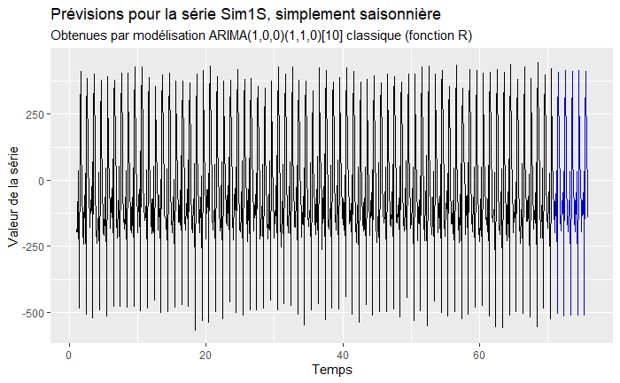

On calcule les prévisions pour notre modèle S3ARMA.

```r
# Utilisation de la fonction func_S3ARMA_part3
forecast_simulation_Sim1S = func_S3ARMA_part3(modele = modele_maison_Sim1S[[2]],
                              nom_modele = modele_maison_Sim1S[[1]],
                              horizon = 50,
                              level = c(80,95),
                              serie_init = Sim1S,
                              d1 = 10, d2 = 0, d3 = 0)
```

```
#######################
### Fonction S3ARMA ###
#######################

Modèle SARMA à saisonnalités multiples
Version 2.0
Paul BOUST

Partie III - Dé-différenciations et Prévisions
----------------------------------------------

### Fin d'éxécution
```

On affiche le résultat graphique :

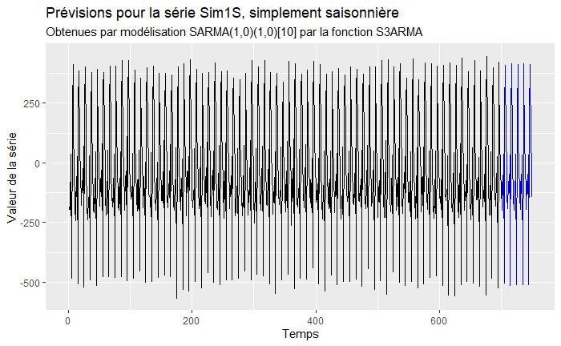

Pour s’en convaincre, on affiche ci-dessous les premières valeur de chacun des objets `forecast`. En premier on trouve les valeurs obtenues de manière classique, tandis qu’en dessous le lecteur trouvera celles obtenues par notre fonction.

```
Fonction Arima classique :

Time Series:
Start = c(71, 1)
End = c(71, 6)
Frequency = 10
[1] -201.23212  -81.68611 -135.10354   36.70128 -504.80976  222.23811
```

```
Fonction func_S3ARMA_part3 :

Time Series:
Start = 701
End = 706
Frequency = 1
[1] -202.36398  -80.77766 -134.45956   37.83198 -505.22664  221.24553
```